# Opening websites from sidebar

In this notebook, I analyse if participants who used the prototype’s “open websites” function more differ from participants who used it less in terms of their TA-EG, SUS, NASA-TLX values or performance.

## Load packages and data

```r
library(WRS2)
library(rcompanion)
library(feather)
library(ggplot2)
library(plyr)
library(ez)
library(schoRsch)
library(MASS)
library(car)
library(ggpubr)
library(rstatix)
library(tidyverse)
library(here)
```

Load a dataframe with participants’ interactions with the system.

```r
df_useractions <- read_feather(path = here('../../data_frames/results_test_02-04-2020_user_actions.file'))
```

```
Coercing int64 to doubleCoercing int64 to doubleCoercing int64 to doubleCoercing int64 to doubleCoercing int64 to doubleCoercing int64 to doubleCoercing int64 to double
```

Load dataframe with the remaining experimental data in wide format.

```r
df_wide <- read_feather(path = here('../../data_frames/results_test_18-03-2020.file'))
```

```
Coercing int64 to doubleCoercing int64 to doubleCoercing int64 to doubleCoercing int64 to doubleCoercing int64 to doubleCoercing int64 to doubleCoercing int64 to doubleCoercing int64 to doubleCoercing int64 to doubleCoercing int64 to doubleCoercing int64 to double
```

## Prepare the data

### Assign participants to the experimental group

- version 1 and 2 –> control group
- version 3 und 4 –> experimental group context free
- version 5 und 6–> experimental group context sensitive

```r
df_wide$group <- ifelse((df_wide$version == 5 | df_wide$version == 6), 'context-sensitive experimental group', ifelse((df_wide$version == 1 | df_wide$version == 2), 'controlgroup', 'context-free experimental group'))
df_useractions$group <- ifelse((df_useractions$version == 5 | df_useractions$version == 6), 'context-sensitive experimental group', ifelse((df_useractions$version == 1 | df_useractions$version == 2), 'controlgroup', 'context-free experimental group'))
```

```r
# Convert trial, group and subject number to factors in each dataframe
df_useractions$trial <- factor(df_useractions$trial, levels = c("tutorial", "warm up", "trial 1", "trial 2", "trial 3"))
df_useractions$group <- factor(df_useractions$group)
df_useractions$partnr <- factor(df_useractions$partnr)
df_wide$group <- factor(df_wide$group)
df_wide$partnr <- factor(df_wide$partnr)
```

### Converting the dataframes

For participants’ interactions with the prototype, we only want the data from participants in the experimental groups whilst working on the experimental tasks.

```r
# exclude interactions during tutorial and warm up
df_trial <- df_useractions[!(df_useractions$trial=="tutorial" | df_useractions$trial=="warm up"), ]
```

```r
# exclude data from the control group
df <- df_trial[!(df_trial$group=="controlgroup"), ]
```

```r
# convert df to wide format
df_w <- pivot_wider(data = df,
                           id_cols = partnr,
                           names_from = trial,
                           values_from = c("add_note", "open_website_from_sidebar"))
```

```r
# include how often participants used the "open websites" function in total
df_w$open_websites_total <- rowSums(df_w[,c("open_website_from_sidebar_trial 1", "open_website_from_sidebar_trial 2", "open_website_from_sidebar_trial 3")])
```

```r
# include a performance measure
df_wide <- transform(df_wide, perf = mistakes_after_interruption / entries_after_interruption)
```

```r
# merge the dataframes with participants' interactions with the prototype and dependent variables
df_ow <- merge(df_wide[,c("partnr", "NASATLX_1", "NASATLX_2", "NASATLX_3", "NASATLX_4", "SUS", "TAEG", "group", "perf")], df_w, by="partnr")
```

We exclude participants 11 and 26 for analysing performance, as we excluded them for the hypothesis testing for performance.

```r
exclude <- list(11, 26)
df_perf <- subset(df_ow, !(df_h$partnr %in% exclude))
```

## Analyse data

### Do participants who used the prototype more have different charactertistics?

### How often have participants used the “open website” function?

```r
table(df_ow$open_websites_total)
```

```
 0  1  2  3  5  6  8  9 10 11 12 14 17 39
10  2  1  1  2  3  5  1  2  3  1  1  1  1
```

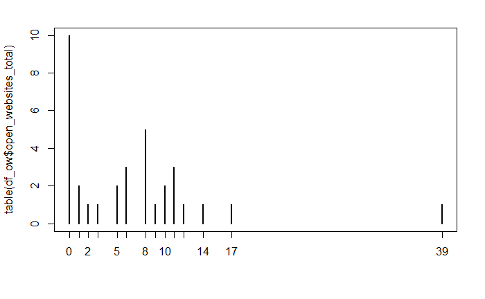

```r
plot(table(df_ow$open_websites_total))
```

```r
median(df_ow$open_websites_total)
```

```
[1] 6
```

```r
mean(df_ow$open_websites_total)
```

```
[1] 6.441176
```

Usage decreases over trials.

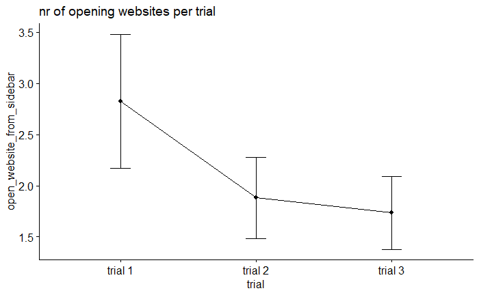

```r
ggline(df, x = "trial", y ="open_website_from_sidebar",
       add = c("mean_se"),
       title = "nr of opening websites per trial")
```

#### correlations with TA-EG, SUS and NASA-TLX

##### TA-EG (n.s.)

There is no significant correlation between frequency of use of the “open website” function and participants’ TA-EG.

```r
cor.test(df_ow$TAEG, df_ow$open_websites_total)
```

```
    Pearson's product-moment correlation

data:  df_ow$TAEG and df_ow$open_websites_total
t = 1.2003, df = 32, p-value = 0.2388
alternative hypothesis: true correlation is not equal to 0
95 percent confidence interval:
 -0.1404524  0.5099430
sample estimates:
      cor
0.2075722
```

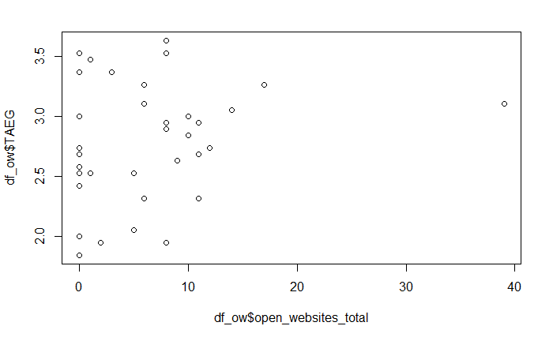

```r
plot(df_ow$open_websites_total, df_ow$TAEG)
```

##### SUS (n.s.)

```r
cor.test(df_ow$SUS, df_ow$open_websites_total)
```

```
    Pearson's product-moment correlation

data:  df_ow$SUS and df_ow$open_websites_total
t = 0.095631, df = 32, p-value = 0.9244
alternative hypothesis: true correlation is not equal to 0
95 percent confidence interval:
 -0.3231097  0.3530506
sample estimates:
       cor
0.01690289
```

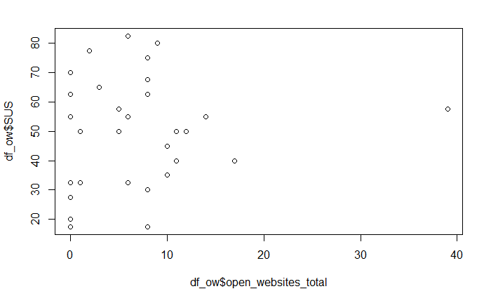

```r
plot(df_ow$open_websites_total, df_ow$SUS)
```

##### NASA-TLX (n.s.)

```r
df_ow$NASATLX_mean <- rowMeans(df_ow[,c("NASATLX_1", "NASATLX_2", "NASATLX_3", "NASATLX_4")])
cor.test(df_ow$NASATLX_mean, df_ow$open_websites_total)
```

```
    Pearson's product-moment correlation

data:  df_ow$NASATLX_mean and df_ow$open_websites_total
t = -0.036277, df = 32, p-value = 0.9713
alternative hypothesis: true correlation is not equal to 0
95 percent confidence interval:
 -0.3438328  0.3324739
sample estimates:
         cor
-0.006412772
```

```r
cor.test(df_ow$NASATLX_2, df_ow$`open_website_from_sidebar_trial 1`)
```

```
    Pearson's product-moment correlation

data:  df_ow$NASATLX_2 and df_ow$`open_website_from_sidebar_trial 1`
t = 0.2084, df = 32, p-value = 0.8362
alternative hypothesis: true correlation is not equal to 0
95 percent confidence interval:
 -0.3051500  0.3703694
sample estimates:
       cor
0.03681461
```

```r
cor.test(df_ow$NASATLX_3, df_ow$`open_website_from_sidebar_trial 2`)
```

```
    Pearson's product-moment correlation

data:  df_ow$NASATLX_3 and df_ow$`open_website_from_sidebar_trial 2`
t = 0.0042967, df = 32, p-value = 0.9966
alternative hypothesis: true correlation is not equal to 0
95 percent confidence interval:
 -0.3374928  0.3388382
sample estimates:
         cor
0.0007595535
```

```r
cor.test(df_ow$NASATLX_4, df_ow$`open_website_from_sidebar_trial 3`)
```

```
    Pearson's product-moment correlation

data:  df_ow$NASATLX_4 and df_ow$`open_website_from_sidebar_trial 3`
t = -1.152, df = 32, p-value = 0.2579
alternative hypothesis: true correlation is not equal to 0
95 percent confidence interval:
 -0.5037246  0.1486456
sample estimates:
       cor
-0.1995509
```

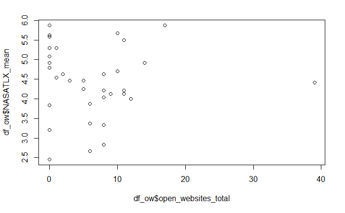

```r
plot(df_ow$open_websites_total, df_ow$NASATLX_mean)
```

We compare participants who have not used the prototype in every trial vs. participants who have used the prototype at least once in every trial, as well as participants who have used the prototype more than average vs. less than average.

```r
#categorize participants
df_ow$usage_every_trial <- ifelse((df_ow$`open_website_from_sidebar_trial 1` == 0 | df_ow$`open_website_from_sidebar_trial 2` == 0 | df_ow$`open_website_from_sidebar_trial 3` == 0), 0, 1)
df_ow$usage_every_trial <- as.factor(df_ow$usage_every_trial)
df_ow$usage_above_average <- ifelse((df_ow$open_websites_total > 6), 1, 0)
df_ow$usage_above_average <- as.factor(df_ow$usage_above_average)
```

#### TA-EG (n.s.)

There is no difference in participants’ TA-EG values for participants with low versus high usage.

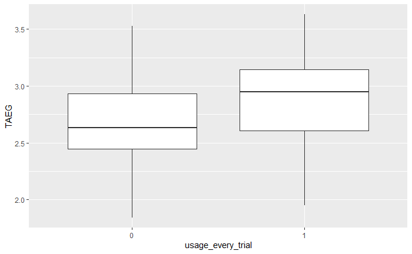

```r
par(mfrow = c(2,1))

ggplot(aes(y = TAEG, x = usage_every_trial), data = df_ow) + geom_boxplot()
```

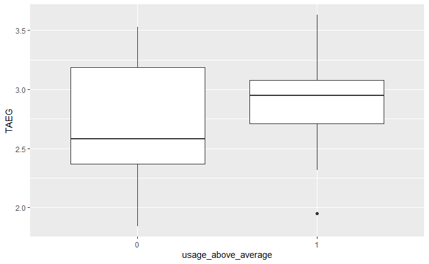

```r
ggplot(aes(y = TAEG, x = usage_above_average), data = df_ow) + geom_boxplot()
```

```r
kruskal.test(df_ow$TAEG, df_ow$usage_every_trial)
```

```
    Kruskal-Wallis rank sum test

data:  df_ow$TAEG and df_ow$usage_every_trial
Kruskal-Wallis chi-squared = 1.4606, df = 1, p-value = 0.2268
```

```r
kruskal.test(df_ow$TAEG, df_ow$usage_above_average)
```

```
    Kruskal-Wallis rank sum test

data:  df_ow$TAEG and df_ow$usage_above_average
Kruskal-Wallis chi-squared = 1.4349, df = 1, p-value = 0.231
```

#### SUS (n.s.)

There are no differences in participants’ SUS scores between participants with low versus high usage.

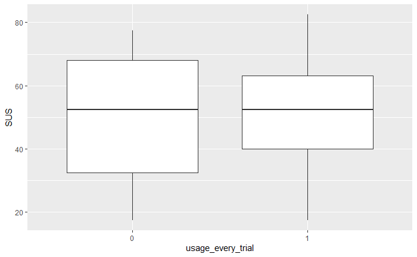

```r
ggplot(aes(y = SUS, x = usage_every_trial), data = df_ow) + geom_boxplot()
```

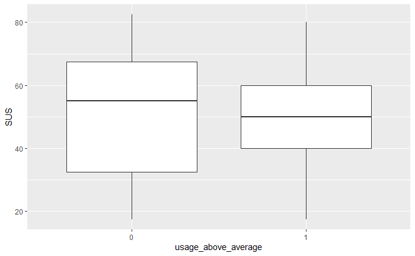

```r
ggplot(aes(y = SUS, x = usage_above_average), data = df_ow) + geom_boxplot()
```

```r
kruskal.test(df_ow$SUS, df_ow$usage_every_trial)
```

```
    Kruskal-Wallis rank sum test

data:  df_ow$SUS and df_ow$usage_every_trial
Kruskal-Wallis chi-squared = 0.037223, df = 1, p-value = 0.847
```

```r
kruskal.test(df_ow$SUS, df_ow$usage_above_average)
```

```
    Kruskal-Wallis rank sum test

data:  df_ow$SUS and df_ow$usage_above_average
Kruskal-Wallis chi-squared = 0.25418, df = 1, p-value = 0.6142
```

##### NASA-TLX (n.s.

There are no significant differences in NASA-TLX for participants with low versus high usage of the function.

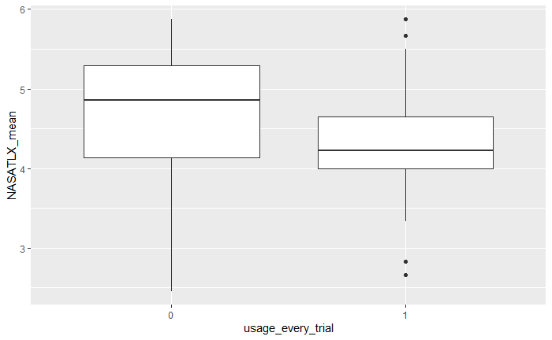

```r
ggplot(aes(y = NASATLX_mean, x = usage_every_trial), data = df_ow) + geom_boxplot()
```

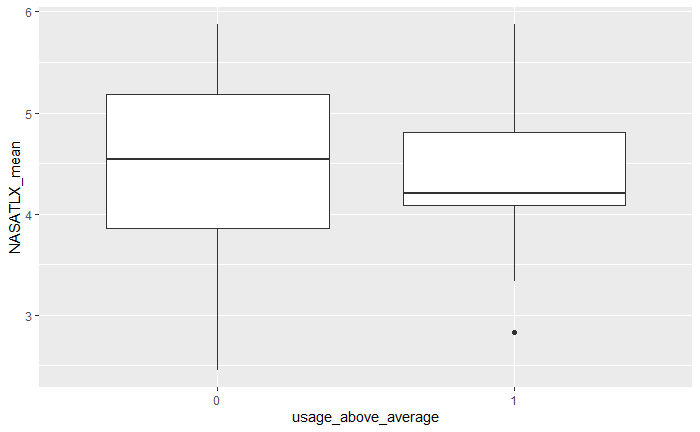

```r
ggplot(aes(y = NASATLX_mean, x = usage_above_average), data = df_ow) + geom_boxplot()
```

```r
kruskal.test(df_ow$NASATLX_mean, df_ow$usage_every_trial)
```

```
    Kruskal-Wallis rank sum test

data:  df_ow$NASATLX_mean and df_ow$usage_every_trial
Kruskal-Wallis chi-squared = 1.8644, df = 1, p-value = 0.1721
```

```r
kruskal.test(df_ow$NASATLX_mean, df_ow$usage_above_average)
```

```
    Kruskal-Wallis rank sum test

data:  df_ow$NASATLX_mean and df_ow$usage_above_average
Kruskal-Wallis chi-squared = 0.08701, df = 1, p-value = 0.768
```

```r
table(df_ow$usage_above_average)
```

```
 0  1
19 15
```

```r
table(df_ow$usage_every_trial)
```

```
 0  1
14 20
```

### Analysis of performance

```r
df_perf$usage_every_trial <- ifelse((df_perf$`open_website_from_sidebar_trial 1` == 0 | df_perf$`open_website_from_sidebar_trial 2` == 0 | df_perf$`open_website_from_sidebar_trial 3` == 0), 0, 1)
df_perf$usage_every_trial <- as.factor(df_perf$usage_every_trial)
mean_open_website_p <- mean(df_perf$open_websites_total)
df_perf$usage_above_average <- ifelse((df_perf$open_websites_total > mean_open_website_p), 1, 0)
df_perf$usage_above_average <- as.factor(df_perf$usage_above_average)
```

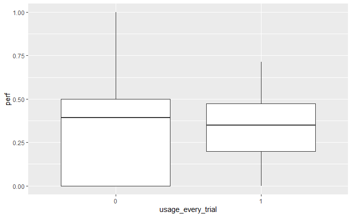

```r
ggplot(aes(y = perf, x = usage_every_trial), data = df_perf) + geom_boxplot()
```

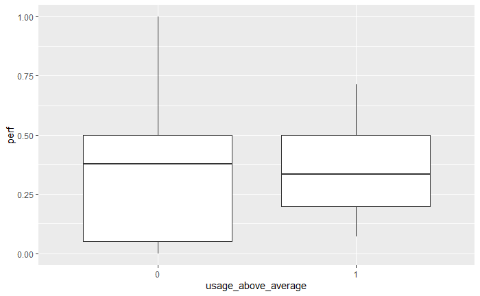

```r
ggplot(aes(y = perf, x = usage_above_average), data = df_perf) + geom_boxplot()
```

```r
cor.test(df_perf$perf, df_perf$open_websites_total)
```

```
    Pearson's product-moment correlation

data:  df_perf$perf and df_perf$open_websites_total
t = -0.32656, df = 31, p-value = 0.7462
alternative hypothesis: true correlation is not equal to 0
95 percent confidence interval:
 -0.3939417  0.2905990
sample estimates:
        cor
-0.05855144
```

```r
kruskal.test(df_perf$perf, df_perf$usage_every_trial)
```

```
    Kruskal-Wallis rank sum test

data:  df_perf$perf and df_perf$usage_every_trial
Kruskal-Wallis chi-squared = 0.012268, df = 1, p-value = 0.9118
```

```r
kruskal.test(df_perf$perf, df_perf$usage_above_average)
```

```
    Kruskal-Wallis rank sum test

data:  df_perf$perf and df_perf$usage_above_average
Kruskal-Wallis chi-squared = 0.0013127, df = 1, p-value = 0.9711
```